# Introduction

Twitter is a wonderful place where people can be whoever they want to be. Will one choose to be their true selves? Their professional selves? Something inbetween? Can we isolate someone's Twitter style? To find out, we'll see if we can create a model that can correctly classify which one of our Penn professors (Alex or Eugen) a tweet came from.

# Methodolgy

Let's walk through our code step by step.

First, we'll load in all of our packages and connect to the Twitter API. We'll create a function that takes an input of a twitter handle and returnsa list of all the tweet objects. We then create a function to turn that list into a dataframe so we can manipulate the data with pandas.

```python
# Set seed for reproducibility
import random; random.seed(123)
# Import all we need from sklearn
from sklearn.feature_extraction.text import CountVectorizer, TfidfVectorizer
from sklearn.model_selection import train_test_split
from sklearn.naive_bayes import MultinomialNB
from sklearn.svm import LinearSVC
from sklearn import metrics
import pandas as pd
from helper_functions import plot_confusion_matrix

import tweepy
import pandas as pd
import pprint
import json

api_key = 'eSEBXtKKjtLltD1PcbnZ4rW2r'
api_secret = 'G0D5AC9HiaHEvpxhacAegugPENllchVg8SL4ynz5EWMV117N9K'
access_token = '1007987784873906177-HI9LK4HTepYlRG6otpeGwy6V82wHPO'
access_token_secret = 'W1k7gfdnw0lseYdno4YIF7WkFD9jGIljh4H6dRLqsFU3a'

auth = tweepy.OAuthHandler(api_key, api_secret)
auth.set_access_token(access_token, access_token_secret)
api = tweepy.API(auth)

def get_users_tweets(user_id):
    tweets = api.user_timeline(
        screen_name=user_id,
        # 200 is the maximum allowed count
        count=200,
        include_rts = False,
        tweet_mode = 'extended'
    )
    all_tweets = []
    all_tweets.extend(tweets)
    oldest_id = tweets[-1].id
    while True:
        tweets = api.user_timeline(screen_name=user_id,
                               # 200 is the maximum allowed count
                               count=200,
                               include_rts = False,
                               max_id = oldest_id - 1,
                               # Necessary to keep full_text
                               # otherwise only the first 140 words are extracted
                               tweet_mode = 'extended'
                               )
        if len(tweets) == 0:
            break
        oldest_id = tweets[-1].id
        all_tweets.extend(tweets)
    return all_tweets

def raw_tweet_to_df(raw_tweets):
    tweets_clean = {
        'created_at' : [],
        'user_name' : [],
        'full_text' : [],
        'fav_count' : [],
        'rt_count' : []
    }
    for tweet in raw_tweets:
        tweet = tweet._json
        tweets_clean['created_at'].append(tweet['created_at'])
        tweets_clean['user_name'].append(tweet['user']['screen_name'])
        tweets_clean['full_text'].append(tweet['full_text'])
        tweets_clean['fav_count'].append(tweet['favorite_count'])
        tweets_clean['rt_count'].append(tweet['retweet_count'])
    tweets_clean_df = pd.DataFrame(tweets_clean)
    return tweets_clean_df

alex_raw = get_users_tweets('shpenev')
dimant_raw = get_users_tweets('eugen_dimant')
alex_df = raw_tweet_to_df(alex_raw)
dimant_df = raw_tweet_to_df(dimant_raw)
```

Since Dimant is way more active on Twitter than Alex and we don't want our model to overweight Dimant's tweets, so we'll randomly sample Dimant's tweets so we have an equal number of Alex and Dimant Tweets. We'll concatenate this data, set the outcome variable as the user's handle, and then split our dataset into training and testing sets.

```python
alex = alex_df
dimant = dimant_df
dimant_sample = dimant.sample(n=270)
shpenev_dimant_trunc = pd.concat([alex, dimant_sample])
shpenev_dimant_df = shpenev_dimant_trunc


# Create target
y = shpenev_dimant_df.user_name

# Split training and testing data
X_train, X_test, y_train, y_test = train_test_split(shpenev_dimant_df['full_text'], y, test_size=0.33,
                 random_state=53)
```

Next, we'll vectorize the data both with a Count Vectorizer and a Tfidf vectorizer to see which performs better.

```python
# Initialize count vectorizer
count_vectorizer = CountVectorizer(stop_words='english',
                                   min_df=0.05, max_df=0.9)

# Create count train and test variables
count_train = count_vectorizer.fit_transform(X_train)
count_test = count_vectorizer.transform(X_test)

# Initialize tfidf vectorizer
tfidf_vectorizer = TfidfVectorizer(stop_words='english', min_df=0.05, max_df=0.9)

# Create tfidf train and test variables
tfidf_train = tfidf_vectorizer.fit_transform(X_train)
tfidf_test = tfidf_vectorizer.transform(X_test)
```

We'll train two Naive Bayes classifiers with the count vectors and the tfidf vectorizer.

# Results

From the data, it seems that both the count vectorizer and the tfidf result in the same accuracy score.

```python
tfidf_nb = MultinomialNB()
tfidf_nb.fit(tfidf_train, y_train)
tfidf_nb_pred = tfidf_nb.predict(tfidf_test)
tfidf_nb_score = metrics.accuracy_score(y_test, tfidf_nb_pred)

count_nb = MultinomialNB()
count_nb.fit(count_train, y_train)
count_nb_pred = count_nb.predict(count_test)
count_nb_score = metrics.accuracy_score(y_test, count_nb_pred)

print('NaiveBayes Tfidf Score: ', tfidf_nb_score)
print('NaiveBayes Count Score: ', count_nb_score)
```

```
NaiveBayes Tfidf Score:  0.5865921787709497
NaiveBayes Count Score:  0.5865921787709497
```

```python
%matplotlib inline


tfidf_nb_cm = metrics.confusion_matrix(y_test, tfidf_nb_pred, labels=['eugen_dimant', 'shpenev'])
count_nb_cm = metrics.confusion_matrix(y_test, count_nb_pred, labels=['eugen_dimant', 'shpenev'])

plot_confusion_matrix(tfidf_nb_cm, classes=['eugen_dimant', 'shpenev'], title="TF-IDF NB Confusion Matrix")

# plot_confusion_matrix(tfidf_nb, tfidf_test, y_test, labels=['eugen_dimant', 'shpenev'])
# plot_confusion_matrix(count_nb, count_test, y_test, labels=['eugen_dimant', 'shpenev'])
```

[output not shown]

```
Confusion matrix, without normalization
```

```python
plot_confusion_matrix(count_nb_cm, classes=['eugen_dimant', 'shpenev'], title="TF-IDF NB Confusion Matrix")
```

[output not shown]

```
Confusion matrix, without normalization
```

Let's now try to use the same data and see if a Suppert Vector Classifier gives us a better score.

```python
tfidf_svc = LinearSVC()
tfidf_svc.fit(tfidf_train, y_train)
tfidf_svc_pred = tfidf_svc.predict(tfidf_test)
tfidf_svc_score = metrics.accuracy_score(y_test, tfidf_svc_pred)

print("LinearSVC Score:   %0.3f" % tfidf_svc_score)

svc_cm = metrics.confusion_matrix(y_test, tfidf_svc_pred, labels=['eugen_dimant', 'shpenev'])
plot_confusion_matrix(svc_cm, classes=['eugen_dimant', 'shpenev'], title="TF-IDF NB Confusion Matrix")
# plot_confusion_matrix(tfidf_svc, tfidf_test, y_test, labels=['eugen_dimant', 'shpenev'])
```

[output not shown]

```
LinearSVC Score:   0.587
Confusion matrix, without normalization
```

Oop, looks like the accuracy score is about the same.

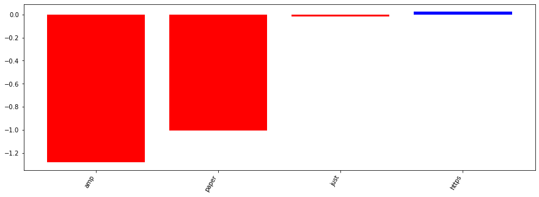

```
[(-1.2815102934827878, 'amp'),
 (-1.0055931180986923, 'paper'),
 (-0.016968063828864736, 'just'),
 (0.02299478781758826, 'https')]
```

```python
from helper_functions import plot_and_return_top_features
from pprint import pprint

top_features = plot_and_return_top_features(tfidf_svc, tfidf_vectorizer)
pprint(top_features)
```

```python
new_alex_tweets = ['Can we all just pretend tomorrow is another Sunday?','Wake up dad. Our bowl is empty.']
new_dimant_tweets = ['Tbh most of Down pointing backhand index findings go against my priors, especially the bit about more females and ECRs.']

for alex_tweet in new_alex_tweets:
    tweet_vector = tfidf_vectorizer.transform([alex_tweet])
    prediction = tfidf_svc.predict(tweet_vector)
    print('Prediction for tweet: {}: {}'.format(alex_tweet, prediction))

for dimant_tweet in new_dimant_tweets:
    tweet_vector = tfidf_vectorizer.transform([dimant_tweet])
    prediction = tfidf_svc.predict(tweet_vector)
    print('Prediction for tweet: {}: {}'.format(dimant_tweet, prediction))
```

```
Prediction for tweet: Can we all just pretend tomorrow is another Sunday?: ['shpenev']
Prediction for tweet: Wake up dad. Our bowl is empty.: ['shpenev']
Prediction for tweet: Tbh most of Down pointing backhand index findings go against my priors, especially the bit about more females and ECRs.: ['shpenev']
```

Finally, we'll pull some tweets from my home timeline and push them through the SVC model we created to see the predictions.

```python
public_tweets = api.home_timeline()

timeline_tweets = []
for tweet in public_tweets:
    tweet_text = tweet._json
    timeline_tweets.append(tweet_text['text'])

for tweet in timeline_tweets:
    tweet_vector = tfidf_vectorizer.transform([tweet])
    prediction = tfidf_svc.predict(tweet_vector)
    print('Prediction for tweet: {}: {}'.format(tweet, prediction))
```

```
Prediction for tweet: Same dude that said
"If we want to sit here and talk about whether a Supreme Court nomination should be based on a… https://t.co/WWRWnDW9DA: ['shpenev']
Prediction for tweet: The Angry Ikea Guy would like a word -- as long as that word is not "Malm"

https://t.co/uxjHL6noVP: ['shpenev']
Prediction for tweet: An exodus of LGBTQ people is beginning in Poland after increased threats of physical violence and an escalation in… https://t.co/z52nVK3UDl: ['shpenev']
Prediction for tweet: RT @judith_ism: Ok sorry but Gottmik didn’t get “third place” they spun a dumb wheel and then a winner gets picked. There’s a top four and…: ['shpenev']
Prediction for tweet: The longer the virus spreads, the greater the chance it mutates into something even more contagious, deadly or vacc… https://t.co/Vu9TpiPj3M: ['shpenev']
Prediction for tweet: Anthony Mackie as Captain America behind the scenes of #TheFalconAndTheWinterSoldier https://t.co/XheM8K9Koo: ['shpenev']
Prediction for tweet: Henne Moving &amp; Storage
Lapeer Avenue
Saginaw, MI https://t.co/W408uGNT5O: ['eugen_dimant']
Prediction for tweet: “I wasn’t at the bridge at Selma, but the struggle for civil rights was the animating political element of my life,… https://t.co/GNRx75QSzD: ['shpenev']
Prediction for tweet: RT @redrawnoxen: we need a film w Daniel day lewis as a controlling, high-strung chef NOW: ['shpenev']
Prediction for tweet: The Circle players Savannah and Terilisha talk face-to-face for the first time since their explosive confrontation… https://t.co/i59qnCQF63: ['shpenev']
Prediction for tweet: Our 2021 MLB predictions, updated after every game → https://t.co/VIqhSADgi6: ['shpenev']
Prediction for tweet: TONIGHT: Sunset Strip Comedy Club is hosting a showcase featuring comics like Adam Ray, Yannis Pappas, and more! https://t.co/uEBn9tKjLx: ['shpenev']
Prediction for tweet: https://t.co/DJojmX6zX4: ['shpenev']
Prediction for tweet: RT @pattymo: https://t.co/P9qTonAzOY: ['shpenev']
Prediction for tweet: RT @scarlettsfx: I'm going to rescan the images from this roll of self portraits I shot in 2019 tonight, any images stand out that you'd li…: ['shpenev']
Prediction for tweet: Here’s our top picks of exactly where to shop for outdoor furniture that inspires and invites: https://t.co/8GlZQqiuhG: ['shpenev']
Prediction for tweet: Day after day the right continues to prove that there are zero good arguments against DC statehood https://t.co/hARgaLl76S: ['shpenev']
Prediction for tweet: OK it's been a month so checking up on this dude's apocalyptic predictions and yeah as you might have expected they… https://t.co/jH9qwc5Whp: ['shpenev']
Prediction for tweet: "People are talking about the Oscars this year," writes @MaureenDowd. "Namely, how they won’t be watching." https://t.co/dLb259KAJx: ['shpenev']
Prediction for tweet: RT @murrman5: [me telling my story how I survived a plane crash and lived on a deserted island for a year] it was crazy
[friend who once go…: ['shpenev']
```

Overall, It looks like in almost all cases our model predicts that these tweets belonged to Alex.

# Conclusion